# I. Importation of the modules

```python
%matplotlib inline
import pandas as pd
import numpy as np
import scipy.stats as stats
import itertools
from math import exp
from IPython.core.pylabtools import figsize
from matplotlib import pyplot as plt
import seaborn as sns
figsize(12.5, 8)
pd.set_option("display.precision", 3)
```

# II. Data-generating process

Here we define variables and code that will allows us to generate the data.

## A. Observational Space

We only consider two observational spaces: the training group and the holdout group.

- $N_{Group}: \text{Number of households in the training/holdout groups}$
- $T_{Group}: \text{Number of weeks in the training/holdout groups}$

We do not model the 25 weeks used to calibrate the loyalty of the household (we instead initialize it from the first purchase observed, see below): instead, we model the behavior of individuals on 120 weeks and discard the first 10. We also assume that all households make one purchase a week.

```python
N_Training = N_Holdout = 300
N_Total = N_Training + N_Holdout

T_Training = T_Holdout = 60
T_Total = T_Training + T_Holdout
```

## B. Product space

Here we define:

- $V_{Sizes}: \text{Vector of sizes}$
- $V_{Brands}: \text{Vector of brands}$

For simplicity, we assume that all brands are available in all sizes.

```python
V_Sizes = np.array([0, 1])
V_Brands = np.array([0, 1, 2, 3, 4])
```

## C. Attribute Space

Here we define several important constants used to generate the data.

### 1°) Loyalty

- $\alpha_B: \text{Smoothing constant of the loyalty for brand}$
- $\alpha_S: \text{Smoothing constant of the loyalty for size}$

### 2°) Prices

- $M_{PriceM}: \text{Price mean matrix for the Brand/Size pairs}$
- $M_{PriceSD}: \text{Price SD matrix for the Brand/Size pairs}$

### 3°) Promotion

- $M_{PromoP}: \text{Probability that a Brand/Size pair is promoted on a given week}$
- $M_{PromoM}: \text{Promotion discount mean matrix for the Brand/Size pairs}$
- $M_{PromoSD}: \text{Promotion discount SD matrix for the Brand/Size pairs}$

```python
alpha_B = 0.875
alpha_S = 0.812

M_priceM = np.array([[3.25, 2.75, 2.65, 4.20, 1.95],[3.00, 2.50, 2.1, 1.5, 2.1]]) #Price is expressed in $/oz in the paper
M_priceSD = np.array([[0.12, 0.05, 0.06, 0.07, 0.09],[0.03, 0.05, 0.07, 0.09, 0.01]]) #We assume very small price variations

M_promoP = np.array([[0.25, 0.35, 0.15, 0.20, 0.12], [0.14, 0.15, 0.18, 0.21, 0.35]]) #Probability of observing a promotion
M_promoM = np.array([[0.15, 0.19, 0.12, 0.26, 0.32], [0.17, 0.28, 0.07, 0.12, 0.4]]) #Promotion is expressed in percentage
M_promoSD = np.array([[0.03, 0.01, 0.02, 0.06, 0.01], [0.01, 0.03, 0.05, 0.05, 0.04]]) #We assume very small variations in magnitude
```

## D. Utility Function

Here we define the utility function and utility parameters of the household i for the brand-size option k at times t:

### 1°) Formulation:

$U_{i, k, t}= \beta^{0}x^{0}_{i, k} + \beta^{1}x^{1}_{k, t} + \beta^{2}x^{2}_{k, t} + \beta^{3}x^{3}_{k, t} + \beta^{4}x^{4}_{i, k, t} + \beta^{5}x^{5}_{i, k, t} + \beta^{6}x^{6}_{i, k, t} + \beta^{7}x^{7}_{i, k, t} +\epsilon_{i, t}$

### 2°) Coefficients description:

- $\beta^{0}$: Fixed utility constants of the brand-size pairs
- $\beta^{1}$: Price factor
- $\beta^{2}$: Promotion factor
- $\beta^{3}$: Promotion discount factor
- $\beta^{4}$: Previous promotion purchase factor
- $\beta^{5}$: Second previous promotion purchase factor
- $\beta^{6}$: Brand Loyalty factor
- $\beta^{7}$: Size Loyalty factor

### 3°) Coefficients determination:

#### a. Paper coefficients:

Using those results in the choice of the 9th option more than 99% of the time, because its price is lower than the other alternatives. For this reason, these coefficients are not used.

```python
b0 = np.array([[0.28, 0.48, 0.99, -1.25, -1.83],[0, -0.06, 0.38, 0.56, 0.33]])
b1 = -29.94
b2 = 2.11
b3 = 29.21
b4 = -0.22
b5= -0.46
b6 = 3.91
b7 = 2.97
```

#### b. Made-up coefficients:

They ensure that the multinomial logit estimation can recover estimates (enough variability in choices)

```python
b0 = np.array([[0, 0.3, 0.5, 0.6, 0.4],[0.7, 0.1, 0.3, 0.1, 0.2]])
b1 = -1.7
b2 = 0.3
b3 = 1.2
b4 = -0.5
b5 = -0.2
b6 = 2.5
b7 = 1.6
```

# III. Dataframes generation

Here we initialize four dataframes:

- $DF_{Supply}: \text{Panel data of Brand/Size pairs characteristics across weeks}$
- $DF_{Demand}: \text{Panel data of household demand across weeks}$
- $DF_{BLoyalty}: \text{Panel data of the Brand loyalties across households and weeks}$
- $DF_{SLoyalty}: \text{Panel data of the Brand loyalties across households and weeks}$

## A. Generation of the Supply dataframe

### 1°) Initialization

```python
weeks = [i for i in range (1, T_Total+1)]
week_pairs_list = [i for i in itertools.product(weeks, V_Sizes, V_Brands)]

weeks_list = pd.DataFrame([i[0] for i in week_pairs_list])
sizes_list = pd.DataFrame([i[1] for i in week_pairs_list])
brands_list = pd.DataFrame([i[2] for i in week_pairs_list])
price_list = promo_list = promosize_list = pd.DataFrame([np.NaN])

DF_Supply = pd.concat([weeks_list, sizes_list, brands_list, price_list, promo_list, promosize_list], axis=1)

colsTime = ["Week", "Size", "Brand", "BasePrice", "Promo", "PromoSize"]
DF_Supply.columns = colsTime
```

### 2°) Definition of the data-generating functions

```python
def gen_random_price(x):
    """
    Given the Size and the Brand, return a
    random price for the time period
    """
    sizeid = x["Size"]
    brandid = x["Brand"]
    price_mean = M_priceM[sizeid][brandid]
    price_SD = M_priceSD[sizeid][brandid]
    return stats.norm.rvs(price_mean, price_SD)

def gen_random_promo(x):
    """
    Given the Size and the Brand, return a
    discount or not for the time period
    """
    sizeid = x["Size"]
    brandid = x["Brand"]
    promo_prob = M_promoP[sizeid][brandid]
    return stats.bernoulli.rvs(promo_prob)

def gen_random_discount(x):
    """
    If the product is discounted on that time period,
    return a discount amount given the Size and the Brand
    """
    if x["Promo"] == 0:
        return 0
    else:
        sizeid = x["Size"]
        brandid = x["Brand"]
        promo_mean = M_promoM[sizeid][brandid]
        promo_SD = M_promoSD[sizeid][brandid]
        return stats.norm.rvs(promo_mean, promo_SD)
```

### 3°) Generation of the BasePrice, Promotion Status and Discount Amount for all the weeks and Brand/Size pairs

```python
DF_Supply["Option"] = DF_Supply["Size"]*5 + DF_Supply["Brand"]
DF_Supply["BasePrice"] = DF_Supply.apply(gen_random_price, axis=1)
DF_Supply["Promo"] = DF_Supply.apply(gen_random_promo, axis=1)
DF_Supply["PromoSize"] = DF_Supply.apply(gen_random_discount, axis=1)
```

### 4°) Fully generated "Supply" dataset:

```python
DF_Supply.head(10)
```

|  | Week | Size | Brand | BasePrice | Promo | PromoSize | Option |
| --- | --- | --- | --- | --- | --- | --- | --- |
| 0 | 1 | 0 | 0 | 3.22 | 0 | 0 | 0 |
| 1 | 1 | 0 | 1 | 2.69 | 0 | 0 | 1 |
| 2 | 1 | 0 | 2 | 2.59 | 0 | 0 | 2 |
| 3 | 1 | 0 | 3 | 4.23 | 0 | 0 | 3 |
| 4 | 1 | 0 | 4 | 1.78 | 0 | 0 | 4 |
| 5 | 1 | 1 | 0 | 3.02 | 0 | 0 | 5 |
| 6 | 1 | 1 | 1 | 2.51 | 0 | 0 | 6 |
| 7 | 1 | 1 | 2 | 2.06 | 0 | 0 | 7 |
| 8 | 1 | 1 | 3 | 1.43 | 0 | 0 | 8 |
| 9 | 1 | 1 | 4 | 2.11 | 0 | 0 | 9 |

## B. Initialization of the Demand dataframe

### 1°) Simulated choices for the first two weeks, and missing values for the following ones

```python
households = [i for i in range(1, N_Total+1)]
households_weeks_list = [i for i in itertools.product(weeks, households)]

weeks_list = pd.DataFrame([i[0] for i in households_weeks_list])
households_list = pd.DataFrame([i[1] for i in households_weeks_list])
sizechoice_list = brandchoice_list = pd.DataFrame([0])

DF_Demand = pd.concat([weeks_list, households_list, sizechoice_list, brandchoice_list], axis=1)
colsPurchase = ["Week", "Household","Size", "Brand"]
DF_Demand.columns = colsPurchase

DF_Demand.loc[DF_Demand.Week==1, "Size"] = np.random.choice([0, 1], size=N_Total)
DF_Demand.loc[DF_Demand.Week==1, "Brand"] = np.random.choice([0, 1, 2, 3, 4], size=N_Total)
DF_Demand.loc[DF_Demand.Week==2, "Size"] = np.random.choice([0, 1], size=N_Total)
DF_Demand.loc[DF_Demand.Week==2, "Brand"] = np.random.choice([0, 1, 2, 3, 4], size=N_Total)
DF_Demand.loc[:, "Option"] =  DF_Demand["Size"]*5 + DF_Demand["Brand"]
```

### 2°) Definition of the data-generating functions for the following weeks

```python
def update_prev_promo(week, past=1):
    """
    Return the brand code if the past purchase was a promotional purchase, otherwise returns a number greater than 10
    """
    colname = "PrevPromo{0}".format(past)
    promo_history = pd.DataFrame(DF_Supply.loc[DF_Supply.Week==(week-past),
                                               ["Brand", "Promo"]]).groupby(["Brand"]).sum().reset_index()
    if week == 3:
        DF_Demand[colname] = np.NaN #Initialize the past brand column

    out = pd.merge(DF_Demand.loc[DF_Demand.Week==(week-past)], promo_history, on=["Brand"], how="left").sort(["Week", "Household"])
    DF_Demand.loc[DF_Demand.Week==week, colname] = np.array(out["Promo"]==0)*10 + np.array(out["Brand"])


def update_all(week):
    """
    Update all the previous period variables, as well as the loyalty
    """
    update_prev_promo(week, past=1)
    update_prev_promo(week, past=2)
    update_BLoyalty(week)
    update_SLoyalty(week)


def gen_choices(week):
    """
    Generate the utility for brand-size options for a given week, and generate a choice of size and brand for all households.
    """
    #Updating the Demand DataFrame to reflect past choices
    update_all(week)
    mask_week = (DF_Supply["Week"] == week)

    #Dataframe of utilities, one row per household
    utilities = pd.DataFrame([[0]*10]*N_Total, columns=["Option_{0}".format(i) for i in range(0, 10)])
    current_week = DF_Demand.loc[DF_Demand.Week==week]

    #Looping over sizes and brands to create the utility  for each option
    for size in V_Sizes:
        mask_size = (DF_Supply["Size"] == size)
        for brand in V_Brands:
            option_number = size*5+brand
            mask_brand = (DF_Supply["Brand"] == brand)

            #Product infos from the Supply dataframe
            product_infos = DF_Supply[mask_week & mask_brand & mask_size]

            #Option-specific utility components (Scalar)
            utility1 = b0[size][brand] + b1*product_infos.iloc[0]["BasePrice"] + \
            b2*product_infos.iloc[0]["Promo"] + b3*product_infos.iloc[0]["PromoSize"]

            #Household-option-specific utility components (Vector of households)
            utility2 = b4*(current_week["PrevPromo1"]==brand) + b5*(current_week["PrevPromo2"]==brand) + \
            b6*DF_BLoyalty.loc[DF_BLoyalty.Week==week, brand] + \
            b7*DF_SLoyalty.loc[DF_SLoyalty.Week==week, size]

            #Assigning the utility in the matrix
            utilities["Option_{0}".format(option_number)] = utility1 + np.array(utility2)


    #Converting the utilities to exp-utilities
    utilities = utilities.applymap(exp)
    utilities["TOTAL"] = utilities.apply(sum, axis=1)

    #Converting the utilities to choice probabilities
    proba = utilities.apply(lambda x: x/x["TOTAL"], axis=1).iloc[:,:-1]

    #Formulating the choice: random sampling of options weighted by choice probabilities
    choice = proba.apply(lambda x: np.random.choice([0, 1, 2, 3, 4, 5, 6, 7, 8, 9], p=np.array(x)), axis=1)

    #Updating the dataframe with the choices
    DF_Demand.loc[DF_Demand.Week==week, "Option"] = np.array(choice)
    DF_Demand.loc[DF_Demand.Week==week, "Size"] = np.array(choice)//5
    DF_Demand.loc[DF_Demand.Week==week, "Brand"] = np.array(choice)%5
```

## C. Initialization of the Brand Loyalty and Size Loyalty dataframes:

```python
households = [i for i in range(1, N_Total+1)]
households_weeks_list = [i for i in itertools.product(weeks, households)]

weeks_list = pd.DataFrame([i[0] for i in households_weeks_list])
households_list = pd.DataFrame([i[1] for i in households_weeks_list])

DF_BLoyalty = pd.concat([weeks_list, households_list], axis=1)
DF_BLoyalty.columns=["Week", "Household"]
for brand in V_Brands:
    DF_BLoyalty[brand] = np.NaN
DF_BLoyalty.columns=["Week", "Household"]+list(V_Brands)

DF_SLoyalty = pd.concat([weeks_list, households_list], axis=1)
DF_SLoyalty.columns=["Week", "Household"]
for size in V_Sizes:
    DF_SLoyalty[size] = np.NaN
DF_SLoyalty.columns=["Week", "Household"]+list(V_Sizes)
```

### 1°) Generating Brand and Size Loyalties in accordance to the first choice of each household (Week 1)

```python
for brand in V_Brands:
    DF_BLoyalty.loc[DF_BLoyalty.Week==1, brand] = \
    alpha_B*(DF_Demand.loc[DF_Demand.Week==1, "Brand"]==brand) + \
    (1-alpha_B)/(V_Brands.shape[0]-1)*(DF_Demand.loc[DF_Demand.Week==1, "Brand"]!=brand)

for size in V_Sizes:
    DF_SLoyalty.loc[DF_SLoyalty.Week==1, size] = \
    alpha_S*(DF_Demand.loc[DF_Demand.Week==1, "Size"]==size) + \
    (1-alpha_S)*(DF_Demand.loc[DF_Demand.Week==1, "Size"]!=size)
```

### 2°) Loyalty generating functions

```python
def update_BLoyalty(week=2):
    for brand in V_Brands:
        new_loyalty = np.array(alpha_B*DF_BLoyalty.loc[DF_BLoyalty.Week==(week-1), brand] + \
        (1-alpha_B)*(DF_Demand.loc[DF_Demand.Week==(week-1), "Brand"]==brand))
        DF_BLoyalty.loc[DF_BLoyalty.Week==week, brand] = new_loyalty

def update_SLoyalty(week=2):
    for size in V_Sizes:
        new_loyalty = np.array(alpha_S*DF_SLoyalty.loc[DF_SLoyalty.Week==(week-1), size] + \
        (1-alpha_S)*(DF_Demand.loc[DF_Demand.Week==(week-1), "Size"]==size))
        DF_SLoyalty.loc[DF_SLoyalty.Week==week, size] = new_loyalty
```

### 3°) Generation of the loyalty data for week 2

```python
update_BLoyalty(week=2)
update_SLoyalty(week=2)
```

### 4°) Fully generated loyalty data for the first two weeks

```python
DF_BLoyalty.head(10)
```

|  | Week | Household | 0 | 1 | 2 | 3 | 4 |
| --- | --- | --- | --- | --- | --- | --- | --- |
| 0 | 1 | 1 | 0.03 | 0.03 | 0.03 | 0.88 | 0.03 |
| 1 | 1 | 2 | 0.03 | 0.88 | 0.03 | 0.03 | 0.03 |
| 2 | 1 | 3 | 0.03 | 0.03 | 0.03 | 0.88 | 0.03 |
| 3 | 1 | 4 | 0.03 | 0.03 | 0.03 | 0.88 | 0.03 |
| 4 | 1 | 5 | 0.03 | 0.03 | 0.03 | 0.03 | 0.88 |
| 5 | 1 | 6 | 0.03 | 0.03 | 0.03 | 0.03 | 0.88 |
| 6 | 1 | 7 | 0.03 | 0.03 | 0.03 | 0.88 | 0.03 |
| 7 | 1 | 8 | 0.03 | 0.03 | 0.03 | 0.88 | 0.03 |
| 8 | 1 | 9 | 0.88 | 0.03 | 0.03 | 0.03 | 0.03 |
| 9 | 1 | 10 | 0.03 | 0.88 | 0.03 | 0.03 | 0.03 |

```python
DF_SLoyalty.head(10)
```

|  | Week | Household | 0 | 1 |
| --- | --- | --- | --- | --- |
| 0 | 1 | 1 | 0.81 | 0.19 |
| 1 | 1 | 2 | 0.81 | 0.19 |
| 2 | 1 | 3 | 0.81 | 0.19 |
| 3 | 1 | 4 | 0.81 | 0.19 |
| 4 | 1 | 5 | 0.81 | 0.19 |
| 5 | 1 | 6 | 0.81 | 0.19 |
| 6 | 1 | 7 | 0.81 | 0.19 |
| 7 | 1 | 8 | 0.19 | 0.81 |
| 8 | 1 | 9 | 0.81 | 0.19 |
| 9 | 1 | 10 | 0.19 | 0.81 |

## D. Generation of the Demand data for all weeks

### 1°) Running the loop

```python
for week in range(3, T_Total+1):
    gen_choices(week)
```

### 2°) Fully generated demand dataset

```python
DF_Demand.loc[DF_Demand.Week>2].head(10)
```

|  | Week | Household | Size | Brand | Option | PrevPromo1 | PrevPromo2 |
| --- | --- | --- | --- | --- | --- | --- | --- |
| 1200 | 3 | 1 | 0 | 4 | 4 | 12 | 13 |
| 1201 | 3 | 2 | 0 | 1 | 1 | 0 | 11 |
| 1202 | 3 | 3 | 1 | 2 | 7 | 12 | 13 |
| 1203 | 3 | 4 | 1 | 3 | 8 | 14 | 13 |
| 1204 | 3 | 5 | 0 | 4 | 4 | 3 | 14 |
| 1205 | 3 | 6 | 0 | 4 | 4 | 3 | 14 |
| 1206 | 3 | 7 | 1 | 3 | 8 | 11 | 13 |
| 1207 | 3 | 8 | 1 | 3 | 8 | 0 | 13 |
| 1208 | 3 | 9 | 1 | 0 | 5 | 14 | 10 |
| 1209 | 3 | 10 | 1 | 1 | 6 | 3 | 11 |

# IV. Creation of the final dataset

## A. Initialization of a PurchaseHistory dataframe

```python
weeks = [i for i in range(3, T_Total+1)]
households = [i for i in range(1, N_Total+1)]
options = [i for i in range(0, 10)]
cols_id = [i for i in itertools.product(weeks, households, options)]

weeks_cols = pd.DataFrame([i[0] for i in cols_id])
households_cols = pd.DataFrame([i[1] for i in cols_id])
options_cols = pd.DataFrame([i[2] for i in cols_id])

DF_PurchaseHistory = pd.concat([weeks_cols, households_cols, options_cols], axis=1)
```

```python
DF_PurchaseHistory.columns = ["Week", "Household", "Option"]
```

## B. Merging the Supply information (price, promotion...) to the PurchaseHistory dataset

```python
DF_PurchaseHistory = pd.merge(DF_PurchaseHistory, DF_Supply, on=["Week", "Option"], how="left").loc[:, ["Week", "Household",
                                                                                               "Size", "Brand", "Option", "BasePrice",
                                                                                                "Promo", "PromoSize"]]
```

## C. Merging the Demand information (choices) to the PurchaseHistory dataset

```python
DF_PurchaseHistory = pd.merge(DF_PurchaseHistory, DF_Demand,
                              on=["Household", "Week", "Size", "Brand", "Option"],
                              how="left").loc[:,["Week", "Household", "Size", "Brand", "Option", "BasePrice", "Promo", "PromoSize"
                                                 ,"PrevPromo1"]]
DF_PurchaseHistory["Chosen"] = ~np.isnan(DF_PurchaseHistory["PrevPromo1"])
```

## D. Merging the Loyalty information to the PurchaseHistory dataset

```python
DF_SLoyalty.columns = ["Week", "Household"] + ["SLoyal{0}".format(i) for i in V_Sizes]
DF_BLoyalty.columns = ["Week", "Household"] + ["BLoyal{0}".format(i) for i in V_Brands]
DF_PurchaseHistory = pd.merge(DF_PurchaseHistory, DF_SLoyalty, on=["Week", "Household"], how="left")
DF_PurchaseHistory = pd.merge(DF_PurchaseHistory, DF_BLoyalty, on=["Week", "Household"], how="left")

DF_PurchaseHistory["BLoyal"] = DF_PurchaseHistory.apply(lambda x: x["BLoyal{0}".format(int(x["Brand"]))], axis=1)
DF_PurchaseHistory["SLoyal"] = DF_PurchaseHistory.apply(lambda x: x["SLoyal{0}".format(int(x["Size"]))], axis=1)

DF_PurchaseHistory = DF_PurchaseHistory.loc[:, ["Week", "Household", "Option", "Chosen", "Size", "Brand", "BasePrice", "Promo",
                                                "PromoSize", "SLoyal", "BLoyal"]]
```

## E. Merging the Previous Promotion information to the PurchaseHistory dataset

### 1°) Lagged Promotion History, by brand

```python
prevpromo1 = DF_Supply.loc[:,["Week", "Brand", "Size", "Promo"]]
prevpromo1.columns = ["Week", "Brand", "Size", "LaggedPromo1"]
prevpromo1["Week"] = prevpromo1["Week"]+1
prevpromo1 = prevpromo1.groupby(["Week", "Brand"]).sum().reset_index()
prevpromo1 = prevpromo1.loc[:,["Week", "Brand", "LaggedPromo1"]].drop_duplicates(["Week", "Brand"])

prevpromo2 = DF_Supply.loc[:,["Week", "Brand", "Size", "Promo"]]
prevpromo2["Week"] = prevpromo2["Week"]+2
prevpromo2.columns = ["Week", "Brand", "Size", "LaggedPromo2"]
prevpromo2.groupby(["Week", "Brand"]).sum().reset_index()
prevpromo2 = prevpromo2.loc[:,["Week", "Brand", "LaggedPromo2"]].drop_duplicates(["Week", "Brand"])
```

### 2°) Lagged choice history, by brand

```python
prevchoice1 = DF_PurchaseHistory.loc[:,["Week", "Household", "Brand", "Size", "Chosen"]]
prevchoice1.columns = ["Week", "Household", "Brand", "Size", "LaggedChoice1"]
prevchoice1["Week"] = prevchoice1["Week"]+1
prevchoice1 = prevchoice1.groupby(["Week", "Household", "Brand"]).sum().reset_index()
prevchoice1 = prevchoice1.loc[:,["Week", "Household", "Brand", "LaggedChoice1"]].drop_duplicates(["Week", "Household", "Brand"])

prevchoice2 = DF_PurchaseHistory.loc[:,["Week", "Household", "Brand", "Size", "Chosen"]]
prevchoice2.columns = ["Week", "Household", "Brand", "Size", "LaggedChoice2"]
prevchoice2["Week"] = prevchoice2["Week"]+2
prevchoice2 = prevchoice2.groupby(["Week", "Household", "Brand"]).sum().reset_index()
prevchoice2 = prevchoice2.loc[:,["Week", "Household", "Brand", "LaggedChoice2"]].drop_duplicates(["Week","Household", "Brand"])
```

### 3°) Merging the promotion and choice status

```python
DF_PurchaseHistory = pd.merge(DF_PurchaseHistory, prevpromo1, on=["Week", "Brand"], how="left")
DF_PurchaseHistory = pd.merge(DF_PurchaseHistory, prevpromo2, on=["Week", "Brand"], how="left")
DF_PurchaseHistory = pd.merge(DF_PurchaseHistory, prevchoice1, on=["Week", "Household", "Brand"], how="left")
DF_PurchaseHistory = pd.merge(DF_PurchaseHistory, prevchoice2, on=["Week", "Household", "Brand"], how="left")
```

### 4°) Creating a dummy variable if the past choice was a promoted brand.

```python
DF_PurchaseHistory["PrevPromo1"] = 1*(DF_PurchaseHistory["LaggedPromo1"]>0)&(DF_PurchaseHistory["LaggedChoice1"]>0)
DF_PurchaseHistory["PrevPromo2"] = 1*(DF_PurchaseHistory["LaggedPromo2"]>0)&(DF_PurchaseHistory["LaggedChoice2"]>0)
```

## F. Dropping unnecessary lines and columns, cleaning the data, preparation for export.

```python
def bool_to_int(x):
    if x == False:
        return 0
    else:
        return 1

DF_PurchaseHistory["PrevPromo1"] = DF_PurchaseHistory["PrevPromo1"].apply(bool_to_int)
DF_PurchaseHistory["PrevPromo2"] = DF_PurchaseHistory["PrevPromo2"].apply(bool_to_int)

DF_PurchaseHistory = DF_PurchaseHistory.loc[DF_PurchaseHistory.Week>4, ["Week", "Household", "Option", "Chosen", "Size", "Brand",
                                                                        "Option", "BasePrice", "Promo", "PromoSize",
                                                                        "SLoyal", "BLoyal", "PrevPromo1", "PrevPromo2"]]

DF_PurchaseHistory["Chosen"] = 1*DF_PurchaseHistory["Chosen"]
DF_PurchaseHistory["ID"] = DF_PurchaseHistory["Week"] * 100 + DF_PurchaseHistory["Household"]
```

## G. Exporting the dataset to CSV, dropping the first 10 weeks.

```python
DF_PurchaseHistory.loc[DF_PurchaseHistory.Week>10].to_csv("PredictionData.csv", index=False)
DF_PurchaseHistory.loc[DF_PurchaseHistory.Week>10].head(10)
```

|  | Week | Household | Option | Chosen | Size | Brand | Option | BasePrice | Promo | PromoSize | SLoyal | BLoyal | PrevPromo1 | PrevPromo2 | ID |
| --- | --- | --- | --- | --- | --- | --- | --- | --- | --- | --- | --- | --- | --- | --- | --- |
| 48000 | 11 | 1 | 0 | 0 | 0 | 0 | 0 | 3.14 | 0 | 0.00 | 0.79 | 0.01 | 0 | 0 | 1101 |
| 48001 | 11 | 1 | 1 | 0 | 0 | 1 | 1 | 2.71 | 0 | 0.00 | 0.79 | 0.12 | 0 | 1 | 1101 |
| 48002 | 11 | 1 | 2 | 0 | 0 | 2 | 2 | 2.64 | 0 | 0.00 | 0.79 | 0.18 | 0 | 0 | 1101 |
| 48003 | 11 | 1 | 3 | 0 | 0 | 3 | 3 | 4.14 | 0 | 0.00 | 0.79 | 0.32 | 0 | 0 | 1101 |
| 48004 | 11 | 1 | 4 | 0 | 0 | 4 | 4 | 1.98 | 1 | 0.33 | 0.79 | 0.37 | 0 | 0 | 1101 |
| 48005 | 11 | 1 | 5 | 0 | 1 | 0 | 5 | 3.05 | 0 | 0.00 | 0.21 | 0.01 | 0 | 0 | 1101 |
| 48006 | 11 | 1 | 6 | 0 | 1 | 1 | 6 | 2.53 | 0 | 0.00 | 0.21 | 0.12 | 0 | 1 | 1101 |
| 48007 | 11 | 1 | 7 | 0 | 1 | 2 | 7 | 2.02 | 0 | 0.00 | 0.21 | 0.18 | 0 | 0 | 1101 |
| 48008 | 11 | 1 | 8 | 0 | 1 | 3 | 8 | 1.48 | 0 | 0.00 | 0.21 | 0.32 | 0 | 0 | 1101 |
| 48009 | 11 | 1 | 9 | 1 | 1 | 4 | 9 | 2.09 | 1 | 0.37 | 0.21 | 0.37 | 0 | 0 | 1101 |

## H. Plotting the size and brand market shares across weeks

```python
brand_share = DF_PurchaseHistory.loc[:,["Week", "Household", "Chosen", "Brand"]].iloc[:,0:4].groupby(["Week", "Household", "Brand"]).sum()
brand_share = brand_share.reset_index()

size_share = DF_PurchaseHistory.loc[:,["Week", "Household", "Chosen", "Size"]].iloc[:,0:4].groupby(["Week", "Household", "Size"]).sum()
size_share = size_share.reset_index()
```

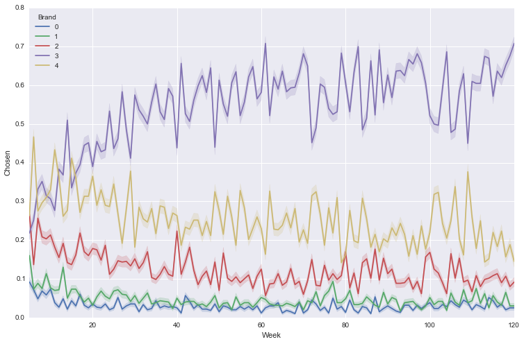

```python
#sns.tsplot(DF_PurchaseHistory, "Week", "Household", "Option", "Chosen")
sns.tsplot(brand_share, time="Week", unit="Household", condition="Brand", value="Chosen", estimator=np.mean)
```

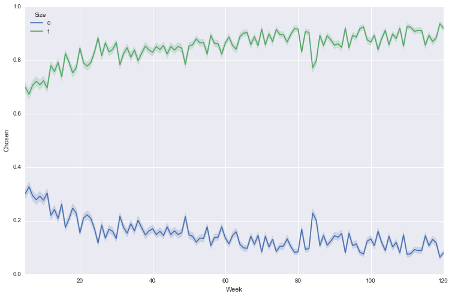

```python
sns.tsplot(size_share, time="Week", unit="Household", condition="Size", value="Chosen", estimator=np.mean)
```

# V. Estimation of the parameters:

## A. In R (using Multinomial logit)

### 1°) Code:

```
library(mlogit)
t <-read.csv('G:\\Dropbox\\Programming\\Notebooks\\PredictionData.csv',header=TRUE, sep=",", dec=".")
mdata = mlogit.data(t, choice="Chosen", shape="long", id.var="ID", alt.var="Option")
res1 <- mlogit(Chosen~BasePrice+Promo+PromoSize+SLoyal+BLoyal+PrevPromo1+PrevPromo2, data=mdata)
summary(res1)
```

### 1°) Results:

```
                            Signif. codes:  0 ‘***’ 0.001 ‘**’ 0.01 ‘*’ 0.05 ‘.’ 0.1 ‘ ’ 1
                            Log-Likelihood: -85404
                            McFadden R^2:  0.10806
                            Likelihood ratio test : chisq = 20694 (p.value = < 2.22e-16)
```

| Coeff. Name | True Coeff. | Coeff. Est. | Std. Err. | t-value | p-value |
| --- | --- | --- | --- | --- | --- |
| Brand 1 | 0.3 | 0.276799 | 0.081838 | 3.3823 | 0.0007189 *** |
| Brand 2 | 0.5 | 0.447918 | 0.083271 | 5.3790 | 7.488e-08 *** |
| Brand 3 | 0.6 | 0.518739 | 0.118180 | 4.3894 | 1.137e-05 *** |
| Brand 4 | 0.4 | 0.392729 | 0.115372 | 3.4040 | 0.0006640 *** |
| Brand 5 | 0.7 | 0.675336 | 0.073672 | 9.1667 | < 2.2e-16 *** |
| Brand 6 | 0.1 | 0.100304 | 0.088500 | 1.1334 | 0.2570552 |
| Brand 7 | 0.3 | 0.324199 | 0.107085 | 3.0275 | 0.0024659 ** |
| Brand 8 | 0.1 | 0.156252 | 0.143384 | 1.0897 | 0.2758263 |
| Brand 9 | 0.2 | 0.216594 | 0.107648 | 2.0120 | 0.0442148 * |
| BasePrice | -1.7 | -1.669881 | 0.072382 | -23.0705 | < 2.2e-16 *** |
| Promo | 0.3 | 0.251315 | 0.022712 | 11.0654 | < 2.2e-16 *** |
| PromoSize | 1.2 | 1.341211 | 0.086205 | 15.5585 | < 2.2e-16 *** |
| PrevPromo1 | -0.5 | -0.478472 | 0.015896 | -30.1009 | < 2.2e-16 *** |
| PrevPromo2 | -0.2 | -0.174632 | 0.021515 | -8.1168 | 4.441e-16 *** |
| SLoyal | 1.6 | 1.542424 | 0.028624 | 53.8853 | < 2.2e-16 *** |
| BLoyal | 2.5 | 2.390669 | 0.024396 | 97.9929 | < 2.2e-16 *** |

## B. In Python (using GLM)

### 1°) Code:

```python
import pandas as pd
import statsmodels.api as sm

cuse = pd.read_csv("PredictionData.csv")
res = sm.formula.glm("Chosen ~ C(Option, Treatment(0)) + BasePrice + Promo + PromoSize + PrevPromo1 + \
                    PrevPromo2 + BLoyal + SLoyal",family=sm.families.Binomial(), data=cuse).fit()
```

### 2°) Results:

```
                                         Generalized Linear Model Regression Results
                        ==============================================================================
                        Dep. Variable:                 Chosen   No. Observations:               660000
                        Model:                            GLM   Df Residuals:                   659983
                        Model Family:                Binomial   Df Model:                           16
                        Link Function:                  logit   Scale:                             1.0
                        Method:                          IRLS   Log-Likelihood:            -1.3450e+05
                        Date:                Mon, 16 Mar 2015   Deviance:                   2.6900e+05
                        Time:                        12:03:30   Pearson chi2:                 6.70e+05
                        No. Iterations:                    11
```

| Coeff. Name | True Coeff. | Coeff. Est. | Std. Err. | t-value | p-value | 95.0% Conf. | Int. |
| --- | --- | --- | --- | --- | --- | --- | --- |
| Intercept | 0 | -0.3019 | 0.241 | -1.255 | 0.209 | -0.773 | 0.170 |
| Brand 1 | 0.3 | 0.2021 | 0.082 | 2.466 | 0.014 | 0.041 | 0.363 |
| Brand 2 | 0.5 | 0.2878 | 0.083 | 3.451 | 0.001 | 0.124 | 0.451 |
| Brand 3 | 0.6 | -0.0918 | 0.119 | -0.774 | 0.439 | -0.324 | 0.141 |
| Brand 4 | 0.4 | 0.1484 | 0.115 | 1.293 | 0.196 | -0.076 | 0.373 |
| Brand 5 | 0.7 | 0.6345 | 0.075 | 8.509 | 0.000 | 0.488 | 0.781 |
| Brand 6 | 0.1 | -0.0090 | 0.089 | -0.101 | 0.920 | -0.183 | 0.165 |
| Brand 7 | 0.3 | 0.1668 | 0.107 | 1.556 | 0.120 | -0.043 | 0.377 |
| Brand 8 | 0.1 | 0.3466 | 0.143 | 2.429 | 0.015 | 0.067 | 0.626 |
| Brand 9 | 0.2 | 0.0376 | 0.108 | 0.350 | 0.727 | -0.173 | 0.248 |
| BasePrice | -1.7 | -1.8030 | 0.072 | -25.172 | 0.000 | -1.943 | -1.663 |
| Promo | 0.3 | 0.3139 | 0.023 | 13.674 | 0.000 | 0.269 | 0.359 |
| PromoSize | 1.2 | 1.0673 | 0.086 | 12.435 | 0.000 | 0.899 | 1.236 |
| PrevPromo1 | -0.5 | -0.4670 | 0.016 | -29.520 | 0.000 | -0.498 | -0.436 |
| PrevPromo2 | -0.2 | -0.1566 | 0.021 | -7.383 | 0.000 | -0.198 | -0.115 |
| SLoyal | 1.6 | 1.4096 | 0.028 | 50.179 | 0.000 | 1.355 | 1.465 |
| BLoyal | 2.5 | 3.2899 | 0.026 | 126.005 | 0.000 | 3.239 | 3.341 |

### 1°) Code:

```python
"""
Implementation of a Conditional/Multinomial Logit Estimation in Python:
In this specification, we assume that all individuals are choosing among
J different options possessing K characteristics.

Each option j has a fixed utility component (Multinomial element), and each
feature k has a fixed parameter common to all options (Conditional element).
The model therefore estimates J + K parameters.

As in Guadagni and Little (1983), we assume that all the options are available
to all individuals at each choice occasion.
@author: Quentin Andre
"""

import pandas as pd
import numpy as np
import scipy.optimize as opt
import scipy.stats as stats

class ChoiceModel(object):
    def __init__(self, data, Y, X, J):
        """
        We initialize the choice model from a Pandas Dataframe in which the
        data is presented in long form (one line per choice and per individual)
            -Data is the Pandas dataframe
            -Y is the name of the column containing the dummy exogenous variable
            -X is the list of columns containing the K endogenous variables
            -J is the column identifying the choice option among J
        The model automatically generate J dummy variables representing
        the fixed utility components for each option.
        """

        #Generating the fixed utility columns
        i = 0
        for option in set(data[J].values):
            data["Option_{}".format(option)] = 1*(data[J] == option)
            X.insert(i, "Option_{}".format(option))
            i += 1
        self.varnames = X

        #Obtaining the endogenous and exogenous components
        self.endog = data.loc[:, Y].values
        self.exog = data.loc[:, X].values

        #Obtaining the number of options
        self._selectors = set(data.loc[:, J])
        self.J = len(self._selectors)
        self.K = self.exog.shape[1]
        self.N = self.exog.shape[0]/self.J

        #Generating an JxNxK array to speed up the computations:
            #The first dimension is the number of options
            #The second dimension is the individual
            #The third dimension is the attribute.
        self._attriblists = []
        for s in self._selectors:
            self._attriblists.append(data.loc[data["Option"]==s,X].values)
        self.attribcubes = np.array(self._attriblists)

    def cdf(self, X):
        """
        CDF of the multinomial logit given a vector X = XB. The utility of the
        first choice is normalized to be 1, to allow identification.
        Return the probability of choice of the option j for the N individuals
        in a JxN matrix, then flattened into a (JxN)x1 array.
        """
        eXB = np.exp(X)
        return (eXB/eXB.sum(0)).flatten(order='F')

    def loglike(self, params):
        """
        Log-likelihood of the choice model.
        The choice probabilities return by the cdf function are
        log-transformed, and summed accross all individuals.
        """
        params = params.reshape(self.K, -1, order='F')
        logprob = np.log(self.cdf(np.dot(self.attribcubes, params)))
        return -np.sum(self.endog * logprob)

    def loglikeobs(self, params):
        """
        Log-likelihood of the choice model.
        Returns the negative log-likelihood function of the observations
        evaluated at `params'. An observation is an option x individual pair.
        """
        params = params.reshape(self.K, -1, order='F')
        logprob = np.log(self.cdf(np.dot(self.attribcubes, params)))
        return (self.endog * logprob)

    def score(self, params):
        """
        Score matrix of the multinomial logit log-likelihood. Used to speed up
        the optimization process of the log-likelihood.
        """
        params = params.reshape(self.K, -1, order='F')
        L = self.cdf(np.dot(self.attribcubes, params))
        return -np.dot(self.endog-L, self.exog)

    def fit_likelihood(self, x0=None, approx_grad=False, true_betas=False):
        """
        Fit the parameters to the data, and obtain the significance level of the
        different parameters compared to 0. If the option "true_betas" is specified,
        then the coefficients will be compared to the true betas as opposed to 0.

        In order to identify the option-constants, the utility of the first option is
        fixed to be 0.
        """
        #Setting the utility of the first option to be 0:
        bounds = [(0, 0)] + [(None, None)]*(self.K-1)
        #Fitting the parameters to the data
        if x0 == None:
            x0 = [0]*self.K
        if approx_grad==False:
            self.fitted = opt.fmin_l_bfgs_b(self.loglike, x0=x0, fprime=self.score, bounds=bounds)
        else:
            self.fitted = opt.fmin_l_bfgs_b(self.loglike, x0=x0, approx_grad=True, bounds=bounds)

        #Storing the estimates in a Pandas dataframe
        norm_dist = stats.norm(loc=0, scale=1)
        betas = self.fitted[0]
        se_betas = []
        var_matrix = np.linalg.inv(self.hessian(betas))
        for i, beta in enumerate(betas):
            se_betas.append(np.sqrt(var_matrix[i][i]))
        self.results = pd.DataFrame(np.array([self.varnames, list(betas), se_betas]).T,
                               columns=["Coeff. Name", "Coeff. Est.", "Std. Err."])
        self.results = self.results.convert_objects(convert_numeric=True)
        if true_betas is not False:
            self.results.insert(1, "True Coeff.", true_betas)
            self.results["t-stat"] = self.results.apply(lambda x: (x["Coeff. Est."]-x["True Coeff."])/x["Std. Err."],
                                                        axis=1)
        else:
            self.results["t-stat"] = self.results.apply(lambda x: x["Coeff. Est;"]/x["Std. Err."],
                                                        axis=1)
        self.results["p-value"] = self.results["t-stat"].apply(lambda x: norm_dist.cdf(-np.abs(x))*2)
        self.results["95% Conf. Int"] = self.results.apply(lambda x: "[{0:.3f}  -  {1:.3f}]".format(
                                                                        x["Coeff. Est."] - x["Std. Err."]*1.96,
                                                                        x["Coeff. Est."] + x["Std. Err."]*1.96
                                                                        ) ,axis=1)
        if self.fitted[2]["warnflag"] == 0:
            return "Convergence achieved! Negative log-likelihood = {0}".format(self.fitted[1])
        else:
            return "The model could not converge!"

    def print_results(self):
        if self.fitted == None:
            return "The parameters must first be estimated!"
        else:
            return self.results

    def hessian(self, params):
        """
        Return the Hessian of the likelihood model, evaluated at `params'.
        """
        params = params.reshape(self.K, -1, order='F')
        L = self.cdf(np.dot(self.attribcubes, params))
        return np.dot(L*(1-L)*self.exog.T,self.exog)
```

### 2°) Estimation

```python
choice_estimation = ChoiceModel(cuse, "Chosen", ["BasePrice", "Promo", "PromoSize", "PrevPromo1",
                                 "PrevPromo2", "BLoyal", "SLoyal"], "Option")
true_betas = np.hstack((b0.flatten(), [b1, b2, b3, b4, b5, b6, b7]))
choice_estimation.fit_likelihood(true_betas=true_betas)
```

```
'Convergence achieved! Negative log-likelihood = 81926.29119348642'
```

### 3°) Results

```python
choice_estimation.print_results()
```

|  | Coeff. Name | True Coeff. | Coeff. Est. | Std. Err. | t-stat | p-value | 95% Conf. Int |
| --- | --- | --- | --- | --- | --- | --- | --- |
| 0 | Option_0 | 0.0 | 0.00 | 0.24 | 0.00 | 1.00 | [-0.471 - 0.471] |
| 1 | Option_1 | 0.3 | 0.32 | 0.20 | 0.10 | 0.92 | [-0.073 - 0.711] |
| 2 | Option_2 | 0.5 | 0.53 | 0.19 | 0.17 | 0.86 | [0.158 - 0.908] |
| 3 | Option_3 | 0.6 | 0.68 | 0.31 | 0.27 | 0.78 | [0.079 - 1.290] |
| 4 | Option_4 | 0.4 | 0.40 | 0.14 | 0.03 | 0.98 | [0.131 - 0.677] |
| 5 | Option_5 | 0.7 | 0.74 | 0.22 | 0.17 | 0.86 | [0.312 - 1.162] |
| 6 | Option_6 | 0.1 | 0.11 | 0.18 | 0.07 | 0.94 | [-0.242 - 0.468] |
| 7 | Option_7 | 0.3 | 0.32 | 0.15 | 0.13 | 0.89 | [0.023 - 0.618] |
| 8 | Option_8 | 0.1 | 0.08 | 0.11 | -0.15 | 0.88 | [-0.133 - 0.299] |
| 9 | Option_9 | 0.2 | 0.18 | 0.15 | -0.14 | 0.89 | [-0.118 - 0.476] |
| 10 | BasePrice | -1.7 | -1.73 | 0.07 | -0.46 | 0.65 | [-1.873 - -1.592] |
| 11 | Promo | 0.3 | 0.29 | 0.02 | -0.29 | 0.77 | [0.249 - 0.338] |
| 12 | PromoSize | 1.2 | 1.17 | 0.08 | -0.40 | 0.69 | [1.001 - 1.332] |
| 13 | PrevPromo1 | -0.5 | -0.50 | 0.02 | -0.10 | 0.92 | [-0.534 - -0.470] |
| 14 | PrevPromo2 | -0.2 | -0.18 | 0.02 | 0.96 | 0.34 | [-0.222 - -0.135] |
| 15 | BLoyal | 2.5 | 2.48 | 0.02 | -0.79 | 0.43 | [2.431 - 2.529] |
| 16 | SLoyal | 1.6 | 1.60 | 0.03 | 0.08 | 0.93 | [1.552 - 1.653] |

With this custom model, the true parameters fall within the 95% confidence interval for the parameters estimates.